# Propser Loan Data Explanation

## by Tosin Kolawole

## Investigation Overview

In this investigation, I looked at the variables that influences Borrower APR.

## Dataset Overview

Prosper loan data contains 113,937 loans from Prosper Funding LLC with 81 variables on each loan, including loan amount, borrower rate (or interest rate), current loan status, borrower income, and many others.

## Distribution of Borrower's APR

The distribution of Borrower's APR appears to be multimodal. We can observe a peak at 0.1 and a bigger one at 0.2. It then goes on a downward trend with another peak at 0.29 and a sudden spike at 0.35.

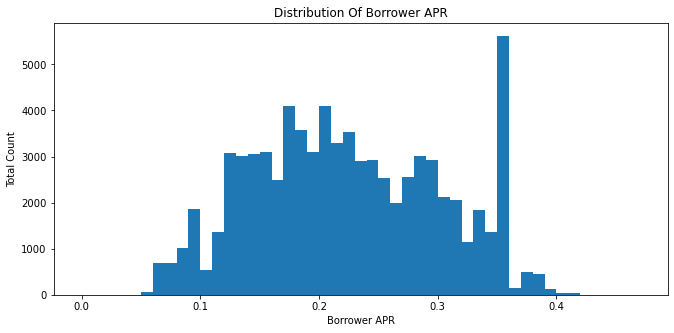

## pairwise correlation between the numerical variables

The Borrower's APR and the Stated Monthly Income are negatively correlated (-0.09) which implies that the higher the income, the lower the APR. The correlation between the Borrower's APR and the Loan Amount is also negatively correlated (-0.40) which also implies that the higher the loan, the lower the APR. Invariably, we can see that the correlation between the Stated Income and Loan amount is positive (0.18), this is justified as the higher the income, the higher the loan you can acccess.

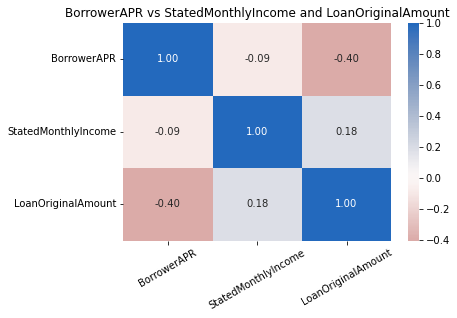

## (Borrower's APR vs prosperRating and IncomeVerifiable)

From the plot, we observe that the prosper rating is a good determinant of the borrower's APR. We can infer from the plot that the higher the rating, the lower the APR and otherwise. Also, Verified income has a lower APR.

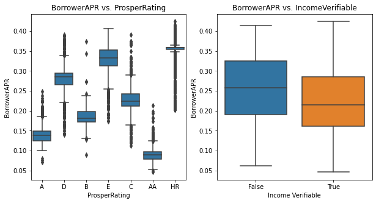